# Markdown i wizualizacja - podstawy

Poniższy segmnt kodu ustawia parametry globalnie dla wszystkich segmentów funkcją z biblioteki knitr `knitr::opts_chunk$set()`. Zaznaczona w naglówku opcja `include=FALSE` oznacza, że ten fragment nie pojawi się w dokumencie wygenerowanym z tego pliku markdown.

# Segmenty tekstowe - formatowanie i najważniejsze informacje

Tekst zwykły

# nagłówek pierwszego poziomu

## nagłówek drugiego poziomiu

### nagłówek trzeciego poziomu

# Formatowanie tekstu[^1]

tekst[^2]

*kursywa* **pogrubienie** `kod` indeks górny <sup>2</sup> indeks dolny <sub>2</sub>

# Nagłowek 1

## Nagłówek 2

listy [@girard1987]

- Element 1. listy wypunktowanej
- Element 2.
  - Element 2a
  - Element 2b
1. Element 1. listy numerowanej
2. Element 2. Numeracja zostanie automatycznie zwiększona w dokumencie wyjściowym.

> block quotes

# Łącza i obrazy

http://rmarkdown.rstudio.com

[R Markdown](http://rmarkdown.rstudio.com)

Obraz z mojego dysku:

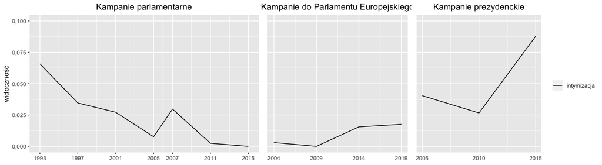

# tabela

**tabela**

Tabele

| Prawy | Lewy | domyślny | Center |
| --- | --- | --- | --- |
| 12 | 12 | 12 | 12 |
| 123 | 123 | 123 | 123 |
| 1 | 1 | 1 | 1 |

```r
data <- faithful[1:4, ]
knitr::kable(data,
 caption = "Tabela z kable")
```

Tabela z kable

| eruptions | waiting |
| --- | --- |
| 3.600 | 79 |
| 1.800 | 54 |
| 3.333 | 74 |
| 2.283 | 62 |

Notatnik. Wykonanie kodu w notatniku sprawia że rezultaty pojawiają się pomiżej kodu.

Przy zapisywaniu notatnika plik HTML zawierajacy kod i jego efekty zostanie zapisany wraz z nim (klikając *Preview* lub skrótem *Cmd+Shift+K* można uzyskać widok preview).

Preview pokazuje wyrenderowaną kopię HTML. Inaczej niż *Knit*, *Preview* nie uruchamia kodu . W preview widać efekt ostatniego uruchomienia kodu w edytorze.

[@grolemund] [@grolemund] To nie jest wersja po renderze tylko pisana, stąd cytowania w tej formie

## Segmenty kodu

Ogólne informacje

Kod w tekście: Dwa dodać dwa to 4

Kod dodajemy *Insert Chunk* na pasku narzędzi albo skrótem *Cmd+Option+I* w Widnows CtrL zamiast cmd

## Opcje segmentów kodu

Opcje segementów są zapisywane w nagłówkach segmentu

`` ``` {r } ``` ``

Format `tag=value`

### nagłówki segmentów kodu (chunk headers)

- nagłówek musi być pisany jako jedna linia -unikać spacji, kropek i podkreślników w etykietach segmentu (chunk labels)

#### Etykieta segmentu

chunk label (n.p, my-chunk ). Tylko ona nie ma taga ., my-chunk, albo label = “my-chunk” Te etykiety muszą być unikalne, segementom bez numeru przypisywane są etykiety takie jak unnamed-chunk-i, gdzie i jest rosnącą liczbą.

### Opcje domyślne

knitr::opts_chunk$set() zmienia domyślne wartości ustawień dla segmentów kodu .

`knitr::opts_chunk$set()`

### Najważniejsze opcje

#### Kod

- `eval`(`TRUE`) czy wykonać fragment kodu czy nie, mozną takżę podać które wyrażenia wykonać za pomocą wektora liczb `eval = c(1,3)`

#### tekst

- `echo` (`TRUE`), czy kod ma być wyświetlony w dokumencie wyjściowym
- `results`:
  - `asis`, pisze rezultaty tak jak są surowy rezutlat bezpośrednio w dokumencie bez znaczników any markups.
  - `markup`, ze znacznikami
  - `hide` lub `FALSE`): ukrywa tekstowe.
- `collapse` czy skolapsować całe źródło i to co wychodzi do jednego bloku
- `warning`: czy zostawić ostrzeżenia w pliku wyjściowym, jeśli `FALSE` to nie
- `error` (`TRUE`), jeśli `FALSE` kod będzie się zatrzymywał na błędach, domyślnie jest na `FALSE`
- `message`Czy zostawić komunikaty emitowane przez `message()`
- `include` czy efekt działania danego segmentu ma zawierać się dokumecie wyjściowym, jeśli `FALSE` nic nie zostanie zapisane w dokumencie wyjsciowym ale kod wciąż będzie wykonany ( na ile rozumiem w Rmarkdown nie ma różnicy między evaluate a execute)

#### Związane z wykresami

- `fig.path` ścieżka do pliku, fig.path i chunk label zostają połączone i tworzą pełną ścieżkę pliku, może być ścieżka do folderu

- `fig.keep`: jak wykresy z segmentu mają być zatrzymane, high, none, all, first ,last
- `fig.show` (`asis`) jak pokazać zaaranżować wykresy, tak jak jest, `hold` na końcu segmentu, `animate` - połącz wykresy w animacje jeśli jest ich wiele, `hide`
- `dev`: pdf dla latex i png dla html markdown, urządzenie graficzne pdf, png, svg, jpeg, tiff, cairo_pdf, CairoJPEG, CairoPNG, svglite, gridSVG, ragg_png, tikz, można sprawdzić `knitr::auto_exts`, mogą być wektory np `dev = c('pdf', 'png')` ten wytworzy dwa wykresy, jeden w pdf drugi w png
- `dev.args` argumenty które można przekazać do urządzenia graficznego
- `dpi`( numeryczna)
- `fig.height()`, `fig.width` numeryczne wysokość i szerokosć w calach
- `fig.asp` stosunek wysokości do szerokości jeśli jest podany, wysokość kalkuluowana jest przez przemnożenie przez ten paramter
- `fig.dim`: wymiary wykresu, = c(szerokość, wysokość)
- `fig.align:` Possible values are default, left, right, and center.
- `fig.retina`: dla html, dla ekranów retina, ustawienie zazwyczaj na dwa zmienia dpi
- `out.width:`, `out.height:` szerokość i wysokość w dokumencie wyjściowym, moze być rózna od fizycznej, wykresy można skalować, może to być procent, w HTML pixele
- `out.extra` - dodatkowe opcje na przykład angle = 90 jako rotacja
- `fig.cap` podpis pod wykresem
- `fig.alt`

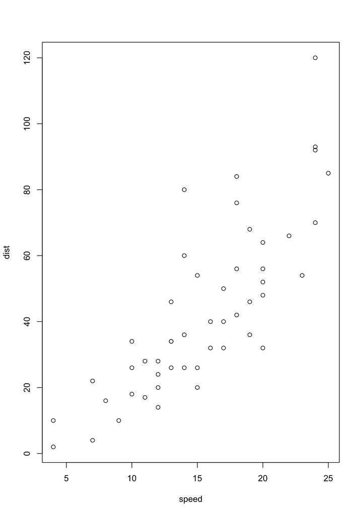

```r
plot(cars) #komentarz
```

# jak umieścić kod z nagłówkiem

https://bookdown.org/yihui/rmarkdown-cookbook/show-header.html

### Bibliografia

[^1]: Przypis numer 1 [@goffman1987]
[^2]: tekst przypisy numerują się automatycznie, ale muszą mieć identyfikatory